# The RNA Centric Analysis System Report

Bora Uyar, Dilmurat Yusuf, Ricardo Wurmus, Altuna Akalin

2016-04-14

# 1 Introduction

RNA Centric Annotation System (RCAS) automatically generates dynamic annotations for custom input files that contain transcriptomic target regions. High-throughput sequencing (HTS) has brought a profound impact on biological research at various levels. At the level of transcriptome, various HTS methods have been applied to study different aspects of the complete set of transcripts that are produced by the genome. On such method is cross-linking immunoprecipitation-high-throughput sequencing (CLIP-Seq) that is used to study RNA binding sites for a protein of interest on a genome-wide scale, thereby increasing the understanding of post-transcriptional regulatory networks. To mitigate the challenge posed by big data generated by HTS methods, automatic solution, such RCAS, is required to to facilitate biological discovery from taget regions located by methods such as Clip-Seq. RCAS automatically provides dynamic annotations for custom input files that contain transcriptomic target regions. Provided with target regions in [BED](http://www.ensembl.org/info/website/upload/bed.html) format( and annotation references in [GFF/GTF](http://www.ensembl.org/info/website/upload/gff.html) format, RCAS automatically summarizes annotated features that overlap with targets, and perform enrichment analysis of motifs, Gene Ontology (GO) terms and gene set. The summary of annotated features consists of intuitive reports in terms of distributions of gene types, genomic features, gene names and coverage profiles. Motif discovery is also one key component of RCAS automatic system. RCAS can provide users list of motifs that are enriched comparing with background sequences. In addition, RCAS generates lists of enriched gene sets and functions to shed light on the functional aspects of target regions. The final report of RCAS consists of high-quality dynamic figures and tables, which are readily applicable for publications or other academic usage.

# 2 Annotation Summary for Query Regions

## 2.1 Distribution of query regions across gene features

**Figure 1 :** The number of query regions that overlap different kinds of gene features are counted. The ‘y’ axis denotes the types of gene features included in the analysis and the ‘x’ axis denotes the percentage of query regions (out of total number of query regions denoted with ‘n’) that overlap at least one genomic interval that host the corresponding feature. Notice that the sum of the percentage values for different features don’t add up to 100%, because some query regions may overlap multiple kinds of features

[interactive chart not shown]

## 2.2 Interactive table of genes that overlap query regions

**Table 1 :** Interactive table of genes that overlap query regions, grouped by gene features such as introns, exons, UTRs, etc.

|  | tx_name | transcripts | exons | promoters | fiveUTRs | introns | exonIntronBoundaries | cds | threeUTRs |
| --- | --- | --- | --- | --- | --- | --- | --- | --- | --- |
| 1 | ENST00000317713 | 33 | 28 | 0 | 0 | 5 | 19 | 24 | 4 |
| 2 | ENST00000361689 | 33 | 28 | 0 | 0 | 5 | 19 | 24 | 4 |
| 3 | ENST00000372915 | 33 | 28 | 0 | 0 | 5 | 19 | 24 | 4 |
| 4 | ENST00000539005 | 33 | 28 | 0 | 0 | 5 | 19 | 24 | 4 |
| 5 | ENST00000545844 | 33 | 28 | 0 | 0 | 5 | 19 | 24 | 4 |
| 6 | ENST00000564288 | 33 | 28 | 0 | 0 | 5 | 19 | 24 | 4 |
| 7 | ENST00000567887 | 33 | 28 | 0 | 0 | 5 | 19 | 24 | 4 |
| 8 | ENST00000372925 | 28 | 23 | 0 | 0 | 5 | 14 | 19 | 4 |
| 9 | ENST00000289893 | 27 | 22 | 0 | 0 | 5 | 13 | 18 | 4 |
| 10 | ENST00000367142 | 14 | 14 | 0 | 0 | 0 | 2 | 3 | 12 |

[output cut: 2087 more lines]

## 2.3 Distribution of query regions in the genome grouped by gene types

**Figure 2 :** The number of query regions that overlap different kinds of gene types are counted. The ‘x’ axis denotes the types of genes included in the analysis and the ‘y’ axis denotes the percentage of query regions (out of total number of query regions denoted with ‘n’) that overlap at least one genomic interval that host the corresponding gene type. If the query regions don’t overlap any known genes, they are classified as ‘Unknown’.

[interactive chart not shown]

## 2.4 Coverage profile of query regions across the length of different gene features

**Figure 3 :** The query regions are overlaid with the genomic coordinates of features. Each entry corresponding to a feature is divided into 100 bins of equal length and for each bin the number of query regions that cover the corresponding bin is counted. Features shorter than 100bp are excluded. Thus, a coverage profile is obtained based on the distribution of the query regions. The strandedness of the features are taken into account. The coverage profile is plotted in the 5’ to 3’ direction.

[interactive chart not shown]

# 3 motifRG analysis results

## 3.1 Top motifs discovered using motifRG

**Figure- 4 :** Top motifs discovered in the sequences of the query regions

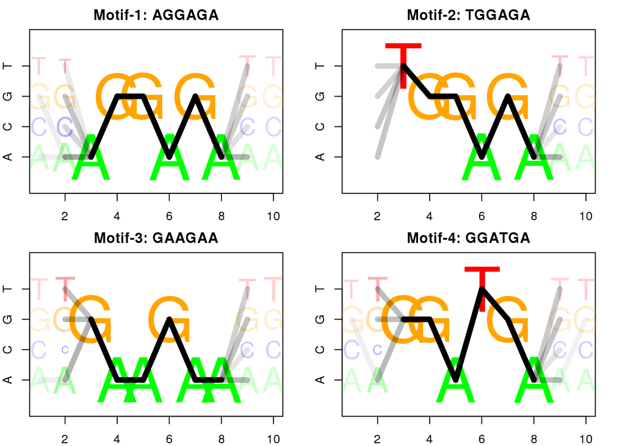

## 3.2 motifRG motif discovery statistics

**Table 2 :** motifRG motif discovery statistics. fg: foreground; bg: background; hits: number of motif hits; seq: number of sequences with motifs; frac: fraction of sequences that contain the motif compared to the all sequences; ratio: ratio of foreground motif fraction versus background motif fraction

|  | patterns | scores | fgHits | bgHits | fgSeq | bgSeq | ratio | fgFrac | bgFrac |
| --- | --- | --- | --- | --- | --- | --- | --- | --- | --- |
| 1 | AGGAGA | 11.1 | 463 | 168 | 451 | 161 | 2.8 | 0.0451 | 0.0161 |
| 2 | TGGAGA | 12.3 | 524 | 176 | 502 | 176 | 3 | 0.0502 | 0.0176 |
| 3 | GAAGAA | 11 | 623 | 254 | 566 | 237 | 2.5 | 0.0566 | 0.0237 |
| 4 | GGATGA | 10.3 | 328 | 98 | 316 | 97 | 3.3 | 0.0316 | 0.0097 |

# 4 GO Term Analysis Results

## 4.1 Biological Processes

**Table 3 :** Significant Biological Process GO terms (BH < 0.1) enriched for genes that overlap query regions

|  | GO.ID | Term | Annotated | Significant | Expected | classicFisher | bonferroni | bh |
| --- | --- | --- | --- | --- | --- | --- | --- | --- |
| 1 | GO:0016071 | mRNA metabolic process | 67 | 35 | 15.08 | 5.4e-08 | 5.6268e-05 | 5.6268e-05 |
| 2 | GO:0016482 | cytoplasmic transport | 105 | 45 | 23.63 | 1.2e-06 | 0.0012504 | 0.0003647 |
| 3 | GO:0044265 | cellular macromolecule catabolic process | 80 | 37 | 18 | 1.2e-06 | 0.0012504 | 0.0003647 |
| 4 | GO:0051641 | cellular localization | 276 | 93 | 62.11 | 1.8e-06 | 0.0018756 | 0.0003647 |
| 5 | GO:0009057 | macromolecule catabolic process | 113 | 47 | 25.43 | 1.9e-06 | 0.0019798 | 0.0003647 |
| 6 | GO:0006401 | RNA catabolic process | 21 | 15 | 4.73 | 2.1e-06 | 0.0021882 | 0.0003647 |
| 7 | GO:0010608 | posttranscriptional regulation of gene e... | 44 | 24 | 9.9 | 2.8e-06 | 0.0029176 | 0.000403775 |
| 8 | GO:0033036 | macromolecule localization | 260 | 88 | 58.51 | 3.1e-06 | 0.0032302 | 0.000403775 |
| 9 | GO:0043604 | amide biosynthetic process | 59 | 29 | 13.28 | 4.2e-06 | 0.0043764 | 0.00044285 |
| 10 | GO:1902582 | single-organism intracellular transport | 150 | 57 | 33.75 | 4.8e-06 | 0.0050016 | 0.00044285 |

[output cut: 1032 more lines]

## 4.2 Molecular Functions

**Table 4 :** Significant Molecular Function GO terms (BH < 0.1) enriched for genes that overlap query regions

|  | GO.ID | Term | Annotated | Significant | Expected | classicFisher | bonferroni | bh |
| --- | --- | --- | --- | --- | --- | --- | --- | --- |
| 1 | GO:0044822 | poly(A) RNA binding | 123 | 66 | 27.25 | 1.7e-15 | 2.754e-13 | 2.754e-13 |
| 2 | GO:0003723 | RNA binding | 152 | 74 | 33.68 | 2.6e-14 | 4.212e-12 | 2.106e-12 |
| 3 | GO:0003676 | nucleic acid binding | 353 | 118 | 78.21 | 2.1e-08 | 3.402e-06 | 1.134e-06 |
| 4 | GO:0097159 | organic cyclic compound binding | 545 | 162 | 120.75 | 2.4e-07 | 3.888e-05 | 9.72e-06 |
| 5 | GO:1901363 | heterocyclic compound binding | 539 | 160 | 119.42 | 3.4e-07 | 5.508e-05 | 1.1016e-05 |
| 6 | GO:0005488 | binding | 1400 | 332 | 310.18 | 0.00024 | 0.03888 | 0.00648 |
| 7 | GO:0019899 | enzyme binding | 162 | 53 | 35.89 | 0.00072 | 0.11664 | 0.0166628571428571 |
| 8 | GO:0005515 | protein binding | 1104 | 270 | 244.6 | 0.00091 | 0.14742 | 0.0184275 |
| 9 | GO:0016491 | oxidoreductase activity | 75 | 28 | 16.62 | 0.00163 | 0.26406 | 0.02934 |
| 10 | GO:0003824 | catalytic activity | 543 | 143 | 120.31 | 0.00286 | 0.46332 | 0.0427090909090909 |

[output cut: 152 more lines]

## 4.3 Cellular Compartments

**Table 5 :** Significant Cellular Compartment GO terms (BH < 0.1) enriched for genes that overlap query regions

|  | GO.ID | Term | Annotated | Significant | Expected | classicFisher | bonferroni | bh |
| --- | --- | --- | --- | --- | --- | --- | --- | --- |
| 1 | GO:0044446 | intracellular organelle part | 769 | 257 | 169.01 | 2.1e-24 | 3.465e-22 | 3.465e-22 |
| 2 | GO:0044422 | organelle part | 788 | 259 | 173.18 | 2.9e-23 | 4.785e-21 | 2.3925e-21 |
| 3 | GO:0043227 | membrane-bounded organelle | 1143 | 329 | 251.2 | 9.2e-23 | 1.518e-20 | 5.06e-21 |
| 4 | GO:0043226 | organelle | 1230 | 343 | 270.32 | 4.1e-22 | 6.765e-20 | 1.69125e-20 |
| 5 | GO:0043229 | intracellular organelle | 1097 | 319 | 241.09 | 7.5e-22 | 1.2375e-19 | 2.475e-20 |
| 6 | GO:0043231 | intracellular membrane-bounded organelle | 997 | 297 | 219.11 | 2.1e-20 | 3.465e-18 | 5.775e-19 |
| 7 | GO:0044424 | intracellular part | 1326 | 349 | 291.42 | 3.0e-16 | 4.95e-14 | 7.07142857142857e-15 |
| 8 | GO:0005622 | intracellular | 1352 | 351 | 297.13 | 5.5e-15 | 9.075e-13 | 1.134375e-13 |
| 9 | GO:0031090 | organelle membrane | 300 | 115 | 65.93 | 7.9e-13 | 1.3035e-10 | 1.44833333333333e-11 |
| 10 | GO:0044444 | cytoplasmic part | 771 | 230 | 169.45 | 2.1e-12 | 3.465e-10 | 3.465e-11 |

[output cut: 155 more lines]

# 5 Gene Set Enrichment Analysis Results

**Table 6 :** Significant MSigDB Gene Sets (BH < 0.1) enriched for genes that overlap query regions

|  | treatment | treatmentSize | expectedInTreatment | fisherPVal | BH | bonferroni |
| --- | --- | --- | --- | --- | --- | --- |
| REACTOME_METABOLISM_OF_PROTEINS | 17 | 418 | 5 | 0.000115027457699236 | 0.0853380800204667 | 0.152986518739983 |
| REACTOME_MRNA_PROCESSING | 12 | 418 | 2.6 | 0.000176905203403173 | 0.0853380800204667 | 0.235283920526221 |
| REACTOME_METABOLISM_OF_RNA | 12 | 418 | 2.8 | 0.000259583616708404 | 0.0853380800204667 | 0.345246210222177 |
| REACTOME_PROCESSING_OF_CAPPED_INTRON_CONTAINING_PRE_MRNA | 11 | 418 | 2.3 | 0.000262044135686793 | 0.0853380800204667 | 0.348518700463435 |
| REACTOME_MRNA_SPLICING | 10 | 418 | 2 | 0.000384983819641203 | 0.0853380800204667 | 0.5120284801228 |
| REACTOME_METABOLISM_OF_MRNA | 10 | 418 | 2 | 0.000384983819641203 | 0.0853380800204667 | 0.5120284801228 |

# 6 Acknowledgements

RCAS is developed by [Dr. Altuna Akalin](http://bioinformatics.mdc-berlin.de/team.html#altuna-akalin-phd) (head of the Scientific Bioinformatics Platform), [Dr. Bora Uyar](http://bioinformatics.mdc-berlin.de/team.html#bora-uyar-phd) (Bioinformatics Scientist), [Dr. Dilmurat Yusuf](http://bioinformatics.mdc-berlin.de/team.html#dilmurat-yusuf-phd) (Bioinformatics Scientist) and [Ricardo Wurmus](http://bioinformatics.mdc-berlin.de/team.html#ricardo-wurmus) (System Administrator) at the Berlin Institute of Medical Systems Biology ([BIMSB](https://www.mdc-berlin.de/13800178/en/bimsb)) at the Max-Delbrueck-Center for Molecular Medicine ([MDC](https://www.mdc-berlin.de)) in Berlin.

RCAS is developed as a bioinformatics service as part of the [RNA Bioinformatics Center](http://www.denbi.de/index.php/rbc), which is one of the eight centers of the German Network for Bioinformatics Infrastructure ([de.NBI](http://www.denbi.de/)).